# Project: Investigate a Dataset Medical Appointment No Shows

This is a dataset from [Kaggle](https://www.google.com/url?q=https://d17h27t6h515a5.cloudfront.net/topher/2017/October/59dd2e9a_noshowappointments-kagglev2-may-2016/noshowappointments-kagglev2-may-2016.csv&sa=D&ust=1532469042118000) that collects information from 110,527 medical appointments in Brazil and is focused on the question of whether or not patients show up for their appointment which contains 14 variables/characteristics. A number of characteristics about the patient are included in each row. The aim of this analyzes is to detect which of the variables affects the show up of a patient.

- ScheduledDay tells us on what day the patient set up their appointment.
- Neighborhood indicates the location of the hospital.
- Scholarship indicates whether or not the patient is enrolled in Brasilian welfare program Bolsa Família.
- Be careful about the encoding of the last column: it says ‘No’ if the patient showed up to their appointment, and ‘Yes’ if they did not show up.
- PatientId: A number that uniquely identifies a patients (Primary Key)

Here in this notebook is on the analysis of patients showing up for their Medical Appointment with asking the following questions.

- Can patient age affect their show-up?
- What is the ratio of gender showing up for an appointment?
- Do we have more female patient than the male?
- Does a particular disease affect the show-up of patients?
- Does a kind of disease affect the show-up of patients?
- What month had the most appointment?
- Does month affect the show up of patients?
- Does sms alert affect the showup of patients for an appointment?
- Does scholarsihp affect the show up of patients?
- Does location of patients affect their show up?

##### Import Required Libraries

```python
#import required libraries
%matplotlib inline
%config InlineBackend.figure_format = 'retina'
import numpy as np
import pandas as pd
import matplotlib.pyplot as plt
import seaborn as sns
sns.set_style('darkgrid')
```

```python
#Read and load medical dataset
df = pd.read_csv('kaggleV2-May-2016.csv')
df.head()
```

|  | PatientId | AppointmentID | Gender | ScheduledDay | AppointmentDay | Age | Neighbourhood | Scholarship | Hipertension | Diabetes | Alcoholism | Handcap | SMS_received | No-show |
| --- | --- | --- | --- | --- | --- | --- | --- | --- | --- | --- | --- | --- | --- | --- |
| 0 | 2.987250e+13 | 5642903 | F | 2016-04-29T18:38:08Z | 2016-04-29T00:00:00Z | 62 | JARDIM DA PENHA | 0 | 1 | 0 | 0 | 0 | 0 | No |
| 1 | 5.589978e+14 | 5642503 | M | 2016-04-29T16:08:27Z | 2016-04-29T00:00:00Z | 56 | JARDIM DA PENHA | 0 | 0 | 0 | 0 | 0 | 0 | No |
| 2 | 4.262962e+12 | 5642549 | F | 2016-04-29T16:19:04Z | 2016-04-29T00:00:00Z | 62 | MATA DA PRAIA | 0 | 0 | 0 | 0 | 0 | 0 | No |
| 3 | 8.679512e+11 | 5642828 | F | 2016-04-29T17:29:31Z | 2016-04-29T00:00:00Z | 8 | PONTAL DE CAMBURI | 0 | 0 | 0 | 0 | 0 | 0 | No |
| 4 | 8.841186e+12 | 5642494 | F | 2016-04-29T16:07:23Z | 2016-04-29T00:00:00Z | 56 | JARDIM DA PENHA | 0 | 1 | 1 | 0 | 0 | 0 | No |

## Data Wrangling

```python
df.info()
df.shape
```

```
<class 'pandas.core.frame.DataFrame'>
RangeIndex: 110527 entries, 0 to 110526
Data columns (total 14 columns):
 #   Column          Non-Null Count   Dtype
---  ------          --------------   -----
 0   PatientId       110527 non-null  float64
 1   AppointmentID   110527 non-null  int64
 2   Gender          110527 non-null  object
 3   ScheduledDay    110527 non-null  object
 4   AppointmentDay  110527 non-null  object
 5   Age             110527 non-null  int64
 6   Neighbourhood   110527 non-null  object
 7   Scholarship     110527 non-null  int64
 8   Hipertension    110527 non-null  int64
 9   Diabetes        110527 non-null  int64
 10  Alcoholism      110527 non-null  int64
 11  Handcap         110527 non-null  int64
 12  SMS_received    110527 non-null  int64
 13  No-show         110527 non-null  object
dtypes: float64(1), int64(8), object(5)
memory usage: 11.8+ MB
```

```
(110527, 14)
```

```python
df.isnull().sum()
```

```
PatientId         0
AppointmentID     0
Gender            0
ScheduledDay      0
AppointmentDay    0
Age               0
Neighbourhood     0
Scholarship       0
Hipertension      0
Diabetes          0
Alcoholism        0
Handcap           0
SMS_received      0
No-show           0
dtype: int64
```

```python
# Checking for any duplicates
df.duplicated().values.any()
```

```
False
```

```python
# Checking for duplicated records
df.duplicated().sum()
```

```
0
```

```python
np.median(df['Age'])
```

```
37.0
```

```python
df.groupby(['Gender'])['Age'].mean()
```

```
Gender
F    38.893987
M    33.736863
Name: Age, dtype: float64
```

```python
df.groupby(['Gender'])['Age'].median()
```

```
Gender
F    39.0
M    33.0
Name: Age, dtype: float64
```

```python
df.groupby(['Gender'])['Age'].std()
```

```
Gender
F    22.155235
M    24.435221
Name: Age, dtype: float64
```

```python
df.describe()
#df.describe().iloc[:,2:]
```

|  | PatientId | AppointmentID | Age | Scholarship | Hipertension | Diabetes | Alcoholism | Handcap | SMS_received |
| --- | --- | --- | --- | --- | --- | --- | --- | --- | --- |
| count | 1.105270e+05 | 1.105270e+05 | 110527.000000 | 110527.000000 | 110527.000000 | 110527.000000 | 110527.000000 | 110527.000000 | 110527.000000 |
| mean | 1.474963e+14 | 5.675305e+06 | 37.088874 | 0.098266 | 0.197246 | 0.071865 | 0.030400 | 0.022248 | 0.321026 |
| std | 2.560949e+14 | 7.129575e+04 | 23.110205 | 0.297675 | 0.397921 | 0.258265 | 0.171686 | 0.161543 | 0.466873 |
| min | 3.921784e+04 | 5.030230e+06 | -1.000000 | 0.000000 | 0.000000 | 0.000000 | 0.000000 | 0.000000 | 0.000000 |
| 25% | 4.172614e+12 | 5.640286e+06 | 18.000000 | 0.000000 | 0.000000 | 0.000000 | 0.000000 | 0.000000 | 0.000000 |
| 50% | 3.173184e+13 | 5.680573e+06 | 37.000000 | 0.000000 | 0.000000 | 0.000000 | 0.000000 | 0.000000 | 0.000000 |
| 75% | 9.439172e+13 | 5.725524e+06 | 55.000000 | 0.000000 | 0.000000 | 0.000000 | 0.000000 | 0.000000 | 1.000000 |
| max | 9.999816e+14 | 5.790484e+06 | 115.000000 | 1.000000 | 1.000000 | 1.000000 | 1.000000 | 4.000000 | 1.000000 |

## Observations

- No word such as Handcap. Renaming of column (Handicap)
- Age has a wrong record (No one can be -1 years old)
- No duplicate records
- Median Ahe is 37.0
- The dataset contain no missing |value
- ScheduledDay and AppointmentDay have incorrect datatype (object instead of **datetime**)
- The dataset contains 14 metadata/columns
- The dataset has 110527 records
- PatientId and AppointmentID has an incorrect datatype (float instead of **object**) but float is used to manage space

  Where 0 = False and 1 = True in column Scholarship, Hipertension, Diabetes, Alcoholism, and SMS_received.

  Where 0 = Not handcap, 1 = fairly-handcap_1, 2 = fairly-handcap_2, 3 = handcap, 4 = highly handcap in column Handcap

### >> Data Cleaning and Manipulation

```python
df.rename(columns={'Handcap':'Handicap'}, inplace=True)
df['ScheduledDay'] = pd.to_datetime(df['ScheduledDay'])
df['AppointmentDay'] = pd.to_datetime(df['AppointmentDay'])
```

```python
df.info()
```

```
<class 'pandas.core.frame.DataFrame'>
RangeIndex: 110527 entries, 0 to 110526
Data columns (total 14 columns):
 #   Column          Non-Null Count   Dtype
---  ------          --------------   -----
 0   PatientId       110527 non-null  float64
 1   AppointmentID   110527 non-null  int64
 2   Gender          110527 non-null  object
 3   ScheduledDay    110527 non-null  datetime64[ns, UTC]
 4   AppointmentDay  110527 non-null  datetime64[ns, UTC]
 5   Age             110527 non-null  int64
 6   Neighbourhood   110527 non-null  object
 7   Scholarship     110527 non-null  int64
 8   Hipertension    110527 non-null  int64
 9   Diabetes        110527 non-null  int64
 10  Alcoholism      110527 non-null  int64
 11  Handicap        110527 non-null  int64
 12  SMS_received    110527 non-null  int64
 13  No-show         110527 non-null  object
dtypes: datetime64[ns, UTC](2), float64(1), int64(8), object(3)
memory usage: 11.8+ MB
```

```python
df.head()
```

|  | PatientId | AppointmentID | Gender | ScheduledDay | AppointmentDay | Age | Neighbourhood | Scholarship | Hipertension | Diabetes | Alcoholism | Handicap | SMS_received | No-show |
| --- | --- | --- | --- | --- | --- | --- | --- | --- | --- | --- | --- | --- | --- | --- |
| 0 | 2.987250e+13 | 5642903 | F | 2016-04-29 18:38:08+00:00 | 2016-04-29 00:00:00+00:00 | 62 | JARDIM DA PENHA | 0 | 1 | 0 | 0 | 0 | 0 | No |
| 1 | 5.589978e+14 | 5642503 | M | 2016-04-29 16:08:27+00:00 | 2016-04-29 00:00:00+00:00 | 56 | JARDIM DA PENHA | 0 | 0 | 0 | 0 | 0 | 0 | No |
| 2 | 4.262962e+12 | 5642549 | F | 2016-04-29 16:19:04+00:00 | 2016-04-29 00:00:00+00:00 | 62 | MATA DA PRAIA | 0 | 0 | 0 | 0 | 0 | 0 | No |
| 3 | 8.679512e+11 | 5642828 | F | 2016-04-29 17:29:31+00:00 | 2016-04-29 00:00:00+00:00 | 8 | PONTAL DE CAMBURI | 0 | 0 | 0 | 0 | 0 | 0 | No |
| 4 | 8.841186e+12 | 5642494 | F | 2016-04-29 16:07:23+00:00 | 2016-04-29 00:00:00+00:00 | 56 | JARDIM DA PENHA | 0 | 1 | 1 | 0 | 0 | 0 | No |

#### Age has a minimum values of -1 which is impossible because no patient can have a negative age.

##### So I'll be filling with +1.

```python
df.at[df.query('Age < 0').index, 'Age'] = 1
```

```python
# Check statistical summary of numerical variables
df.describe()
```

|  | PatientId | AppointmentID | Age | Scholarship | Hipertension | Diabetes | Alcoholism | Handicap | SMS_received |
| --- | --- | --- | --- | --- | --- | --- | --- | --- | --- |
| count | 1.105270e+05 | 1.105270e+05 | 110527.000000 | 110527.000000 | 110527.000000 | 110527.000000 | 110527.000000 | 110527.000000 | 110527.000000 |
| mean | 1.474963e+14 | 5.675305e+06 | 37.088892 | 0.098266 | 0.197246 | 0.071865 | 0.030400 | 0.022248 | 0.321026 |
| std | 2.560949e+14 | 7.129575e+04 | 23.110176 | 0.297675 | 0.397921 | 0.258265 | 0.171686 | 0.161543 | 0.466873 |
| min | 3.921784e+04 | 5.030230e+06 | 0.000000 | 0.000000 | 0.000000 | 0.000000 | 0.000000 | 0.000000 | 0.000000 |
| 25% | 4.172614e+12 | 5.640286e+06 | 18.000000 | 0.000000 | 0.000000 | 0.000000 | 0.000000 | 0.000000 | 0.000000 |
| 50% | 3.173184e+13 | 5.680573e+06 | 37.000000 | 0.000000 | 0.000000 | 0.000000 | 0.000000 | 0.000000 | 0.000000 |
| 75% | 9.439172e+13 | 5.725524e+06 | 55.000000 | 0.000000 | 0.000000 | 0.000000 | 0.000000 | 0.000000 | 1.000000 |
| max | 9.999816e+14 | 5.790484e+06 | 115.000000 | 1.000000 | 1.000000 | 1.000000 | 1.000000 | 4.000000 | 1.000000 |

```python
df.query('Age == -1') #Cleaned
```

|  | PatientId | AppointmentID | Gender | ScheduledDay | AppointmentDay | Age | Neighbourhood | Scholarship | Hipertension | Diabetes | Alcoholism | Handicap | SMS_received | No-show |
| --- | --- | --- | --- | --- | --- | --- | --- | --- | --- | --- | --- | --- | --- | --- |

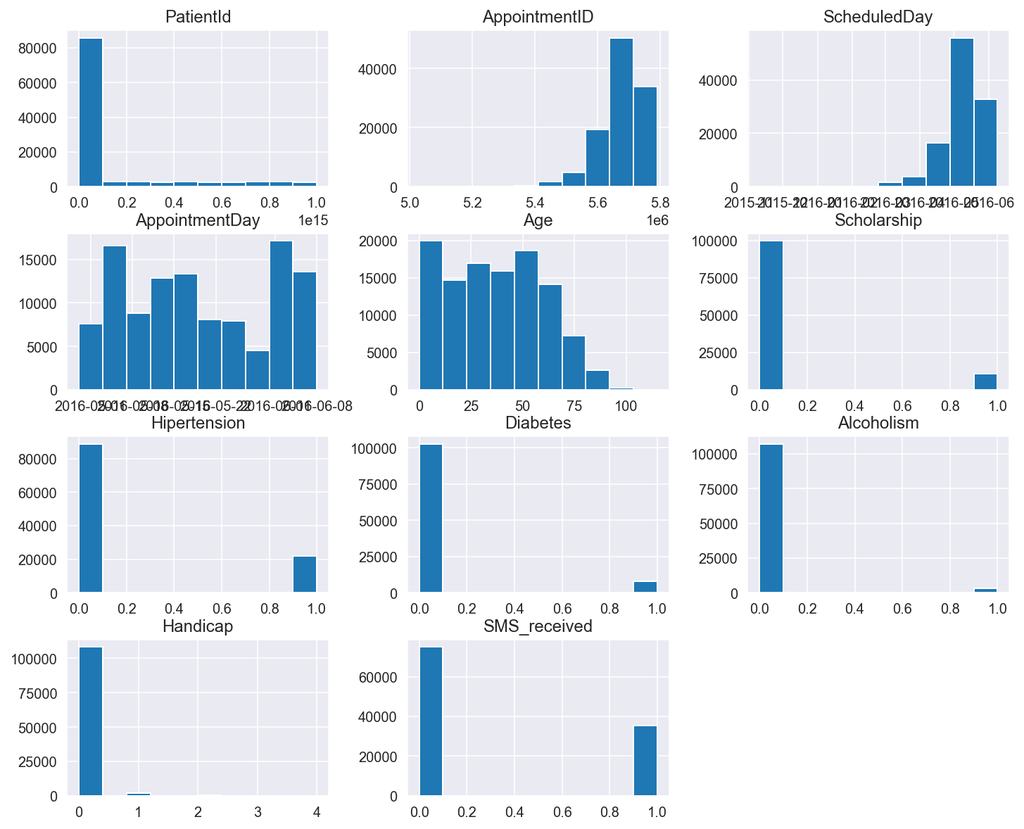

```python
df.hist(figsize = (12, 10));
```

```python
#df.query('Age < 0').count()
df[(df['Age'] > 0) & (df['Age'] < 13)].count() #
```

```
PatientId         17498
AppointmentID     17498
Gender            17498
ScheduledDay      17498
AppointmentDay    17498
Age               17498
Neighbourhood     17498
Scholarship       17498
Hipertension      17498
Diabetes          17498
Alcoholism        17498
Handicap          17498
SMS_received      17498
No-show           17498
dtype: int64
```

*We can see from the plot that we have more patients between the age of 0 and 12.5 years old and few aged patients.*

*So can age affect the number of show-up? Let's find out in Q1*

## Descriptive and Exploratory Data Analysis

> Descriptive

```python
df.describe().T
```

|  | count | mean | std | min | 25% | 50% | 75% | max |
| --- | --- | --- | --- | --- | --- | --- | --- | --- |
| PatientId | 110527.0 | 1.474963e+14 | 2.560949e+14 | 3.921784e+04 | 4.172614e+12 | 3.173184e+13 | 9.439172e+13 | 9.999816e+14 |
| AppointmentID | 110527.0 | 5.675305e+06 | 7.129575e+04 | 5.030230e+06 | 5.640286e+06 | 5.680573e+06 | 5.725524e+06 | 5.790484e+06 |
| Age | 110527.0 | 3.708889e+01 | 2.311018e+01 | 0.000000e+00 | 1.800000e+01 | 3.700000e+01 | 5.500000e+01 | 1.150000e+02 |
| Scholarship | 110527.0 | 9.826558e-02 | 2.976748e-01 | 0.000000e+00 | 0.000000e+00 | 0.000000e+00 | 0.000000e+00 | 1.000000e+00 |
| Hipertension | 110527.0 | 1.972459e-01 | 3.979213e-01 | 0.000000e+00 | 0.000000e+00 | 0.000000e+00 | 0.000000e+00 | 1.000000e+00 |
| Diabetes | 110527.0 | 7.186479e-02 | 2.582651e-01 | 0.000000e+00 | 0.000000e+00 | 0.000000e+00 | 0.000000e+00 | 1.000000e+00 |
| Alcoholism | 110527.0 | 3.039981e-02 | 1.716856e-01 | 0.000000e+00 | 0.000000e+00 | 0.000000e+00 | 0.000000e+00 | 1.000000e+00 |
| Handicap | 110527.0 | 2.224796e-02 | 1.615427e-01 | 0.000000e+00 | 0.000000e+00 | 0.000000e+00 | 0.000000e+00 | 4.000000e+00 |
| SMS_received | 110527.0 | 3.210256e-01 | 4.668727e-01 | 0.000000e+00 | 0.000000e+00 | 0.000000e+00 | 1.000000e+00 | 1.000000e+00 |

```python
# Function
def percentage(x,y):
    return (x*100)/len(y)
```

## Q1: Can patient age affect their show-up?

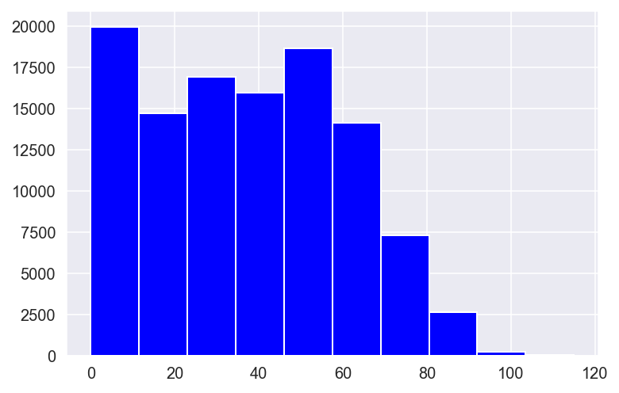

```python
pd.DataFrame(df['Age'].describe())
df['Age'].hist(color='b');
```

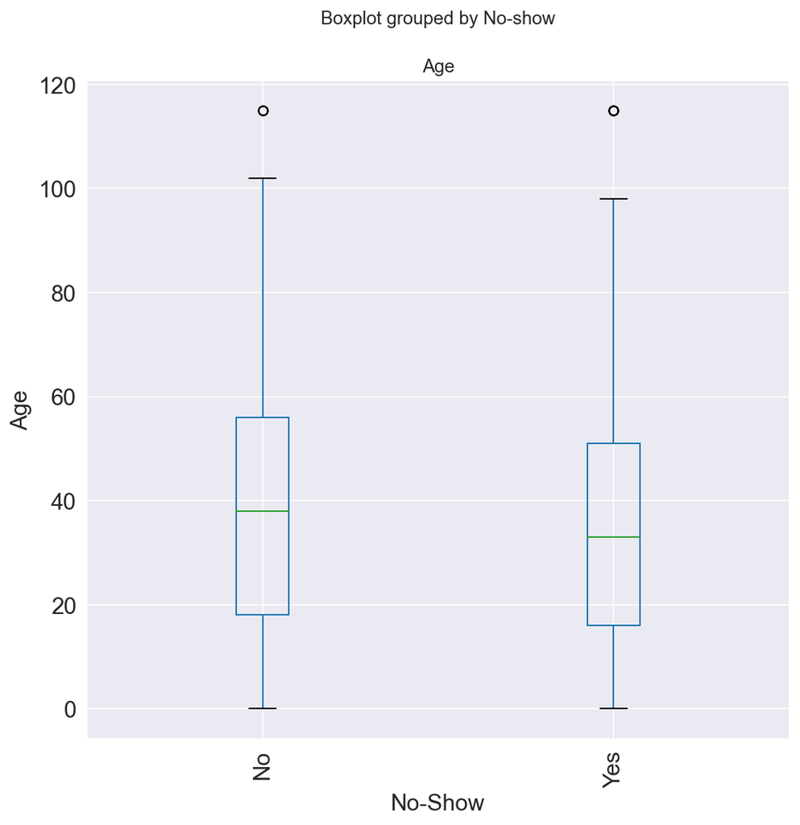

```python
df.boxplot('Age', by="No-show", rot=90, figsize=(8,8), fontsize=15)
plt.ylabel('Age', fontsize=15);
plt.xlabel('No-Show', fontsize=15);
```

```python
pd.DataFrame(df.groupby('No-show')['Age'].describe().loc[:,['mean','std']])
```

| No-show | mean | std |
| --- | --- | --- |
| No | 37.790087 | 23.338842 |
| Yes | 34.317667 | 21.965941 |

```python
# Cutting continuous variables (Age) into segments.

bin_edges = [0, 20, 40, 60, 80, 100, 120]
bin_names = ['Child/Teenager', 'Young Adult', 'Adult', 'Elder', 'More Elderly', 'Aged']
df['age_category'] = pd.cut(df['Age'], bin_edges, labels = bin_names)

df_age = df[['Age','No-show', 'age_category']].groupby(['age_category', 'No-show']).count().sort_values(by='Age', ascending= False).unstack()
df_age
```

| No-show age_category | Age No | Age Yes |
| --- | --- | --- |
| Child/Teenager | 21853 | 6457 |
| Young Adult | 22209 | 6626 |
| Adult | 24490 | 5591 |
| Elder | 14373 | 2537 |
| More Elderly | 2379 | 466 |
| Aged | 4 | 3 |

```python
# Age categories in percentage
df_age = df[['Age','No-show', 'age_category']].groupby(['age_category', 'No-show']).count().sort_values(by='Age', ascending= False)
df_age = percentage(df_age, df).unstack()
df_age
```

| No-show age_category | Age No | Age Yes |
| --- | --- | --- |
| Child/Teenager | 19.771640 | 5.842011 |
| Young Adult | 20.093733 | 5.994915 |
| Adult | 22.157482 | 5.058492 |
| Elder | 13.004062 | 2.295367 |
| More Elderly | 2.152415 | 0.421616 |
| Aged | 0.003619 | 0.002714 |

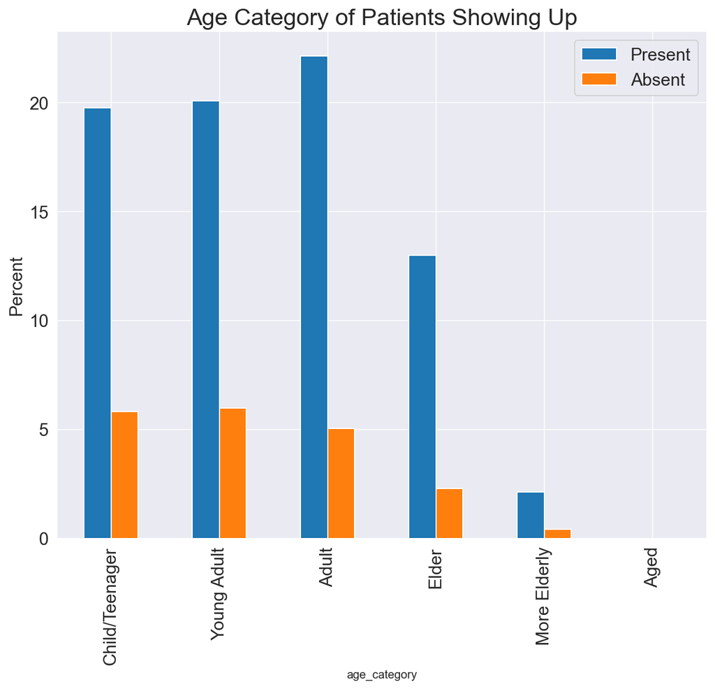

```python
#Visualization of Age categories
df_age.plot(kind ='bar', stacked = False, fontsize = 15, figsize = (10,8));
plt.ylabel('Percent', fontsize=15)
plt.title('Age Category of Patients Showing Up', fontsize=20)
plt.legend(['Present', 'Absent'],  fontsize=15);
```

*It is noticed that patient of the age category 40 - 60 (adult) showed up for their appointment. We can say age affects the appearance of patients because patient between the age of 0 - 60 maybe due to the fact of being health conscious and strength to visit the clinic*

## Q2: What is the ratio of gender showing up for an appointment?

```python
# Finding which gender showed up the most for their appointment
df_gender = df.groupby('Gender')['No-show'].value_counts()
df_gender = percentage(df_gender, df).unstack()
df_gender
```

| No-show Gender | No | Yes |
| --- | --- | --- |
| F | 51.793679 | 13.204013 |
| M | 28.013065 | 6.989242 |

*52% female and 28% male showed up for their appointment. i.e 80% of the total population*

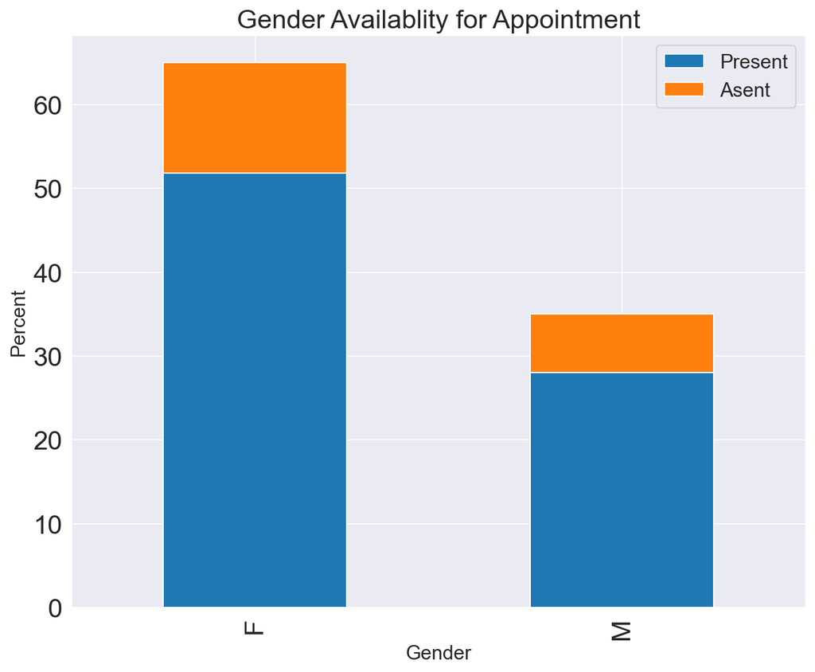

```python
# Visualization of gender availability to show up for an appointment
df_gender.plot(kind = 'bar', stacked = True, fontsize = 20, figsize=(10, 8));
plt.xlabel('Gender', fontsize=15)
plt.ylabel('Percent', fontsize=15)
plt.title('Gender Availablity for Appointment', fontsize=20)
plt.legend(['Present', 'Asent'], fontsize=15);
```

*We can see that there are more female patients than male patients who showed up for an appointment. 52% female and 28% male of the total number of patients showed up*

## Q3: Do we have more female patient than the male?

```python
# In percentage ratio
df_sex = df['Gender'].value_counts()
df_sex = percentage(df_sex, df)
```

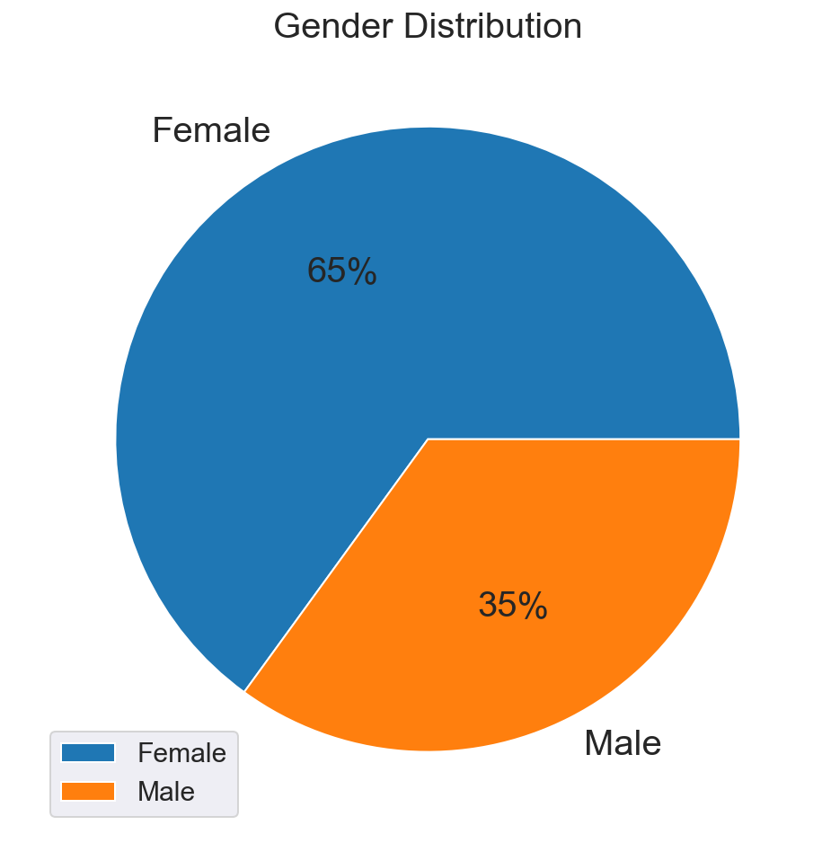

```python
#Visualization of gender availability
label = ['Female','Male']
df_sex.plot(kind = 'pie',labels = label,fontsize=20, figsize = (15,8),  autopct = '%1.0f%%')
plt.title('Gender Distribution',fontsize=20)
plt.legend(['Female','Male'], fontsize=15)
plt.ylabel(' ')
```

```python
df.groupby(['Gender'])[['PatientId']].count()
```

| Gender | PatientId |
| --- | --- |
| F | 71840 |
| M | 38687 |

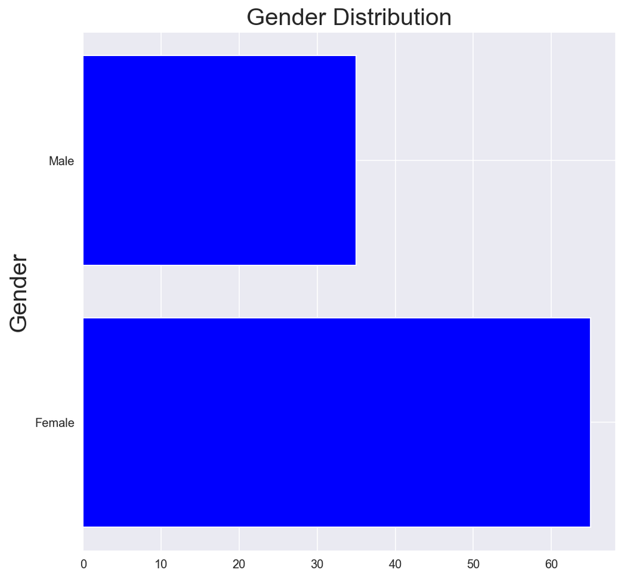

```python
plt.figure(figsize=(8,8))
plt.barh([1,2],[df_sex[0], df_sex[1]], tick_label = ['Female', 'Male'], color ='b');
plt.title('Gender Distribution',fontsize=20)
plt.ylabel('Gender', fontsize=20)
```

- Why do more female patients show-up than male patients
  - Do more female get scholarship?
  - Do more female stay close to the clinic?
  - Do more female get sms than male patients?

> ANALYZING WHAT FEATURES FROM THE DATASET AFFECTS THE SHOW-UP OF PATIENTS

## Q4: Does a particular disease affect the show-up of patients?

*0 : has no aliment* *1 : has an aliment*

> Hipertension

```python
# Patients with Hypertension
df_Hiptertension = percentage(df.groupby(['Hipertension','No-show']).count(), df)
df_Hiptertension= df_Hiptertension.pivot_table(values='PatientId', index='Hipertension', columns='No-show')
df_Hiptertension
```

| No-show Hipertension | No | Yes |
| --- | --- | --- |
| 0 | 63.494893 | 16.780515 |
| 1 | 16.311851 | 3.412741 |

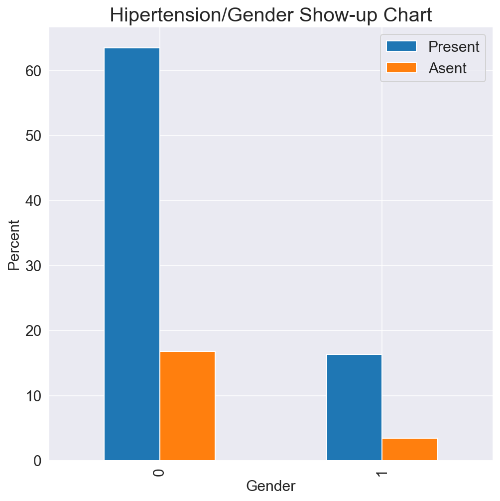

```python
df_Hiptertension.plot(kind='bar', figsize=(8,8), fontsize=15);
plt.xlabel('Gender', fontsize=15)
plt.ylabel('Percent', fontsize=15)
plt.title('Hipertension/Gender Show-up Chart', fontsize=20)
plt.legend(['Present', 'Asent'],  fontsize=15);
```

> Diabetes

```python
# Patients with Diabetes
df_Diabetes = percentage(df.groupby(['Diabetes','No-show']).count(), df)
df_Diabetes= df_Diabetes.pivot_table(values='PatientId', index='Diabetes', columns='No-show')
df_Diabetes
```

| No-show Diabetes | No | Yes |
| --- | --- | --- |
| 0 | 73.914066 | 18.899454 |
| 1 | 5.892678 | 1.293802 |

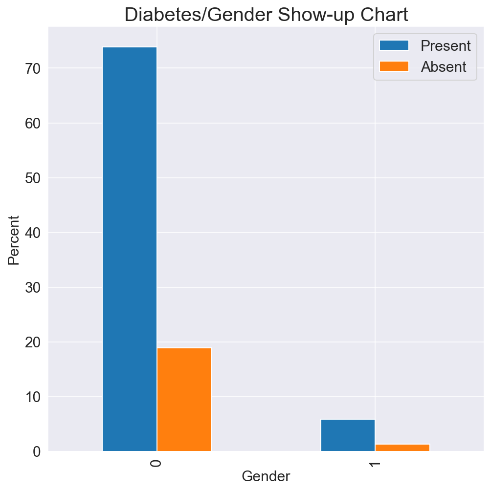

```python
df_Diabetes.plot(kind='bar', figsize=(8,8), fontsize=15);
plt.xlabel('Gender', fontsize=15)
plt.ylabel('Percent', fontsize=15)
plt.title('Diabetes/Gender Show-up Chart', fontsize=20)
plt.legend(['Present', 'Absent'],  fontsize=15);
```

> Alcoholism

```python
# Patients with Alcoholism
df_Alcoholism = df.groupby(['Alcoholism','No-show']).count()*100/len(df)
df_Alcoholism= df_Alcoholism.pivot_table(values='PatientId', index='Alcoholism', columns='No-show')
df_Alcoholism
```

| No-show Alcoholism | No | Yes |
| --- | --- | --- |
| 0 | 77.379283 | 19.580736 |
| 1 | 2.427461 | 0.612520 |

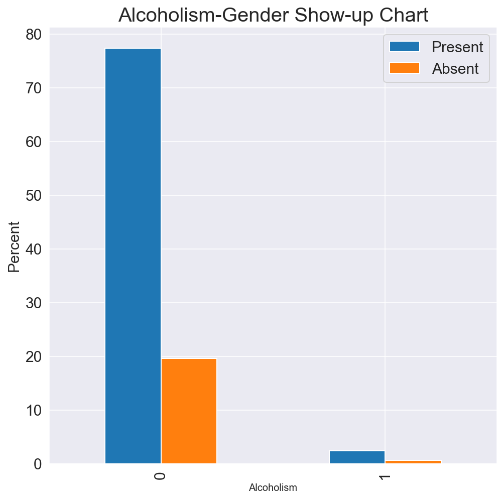

```python
df_Alcoholism.plot(kind='bar', figsize=(8,8), fontsize=15);
plt.ylabel('Percent', fontsize=15)
plt.title('Alcoholism-Gender Show-up Chart', fontsize=20)
plt.legend(['Present', 'Absent'],  fontsize=15);
```

> Handicap

```python
# Patients that are handicapped
df_handicap = percentage(df.groupby(['Handicap','No-show']).count(), df)
df_handicap = df_handicap.pivot_table(values='PatientId', index='Handicap', columns='No-show', aggfunc=sum)
df_handicap
```

| No-show Handicap | No | Yes |
| --- | --- | --- |
| 0 | 78.147421 | 19.825020 |
| 1 | 1.516372 | 0.331141 |
| 2 | 0.132094 | 0.033476 |
| 3 | 0.009048 | 0.002714 |
| 4 | 0.001810 | 0.000905 |

```python
df_handicap = df_handicap[['Yes', 'No']].sum()
df_handicap
```

```
No-show
Yes    20.193256
No     79.806744
dtype: float64
```

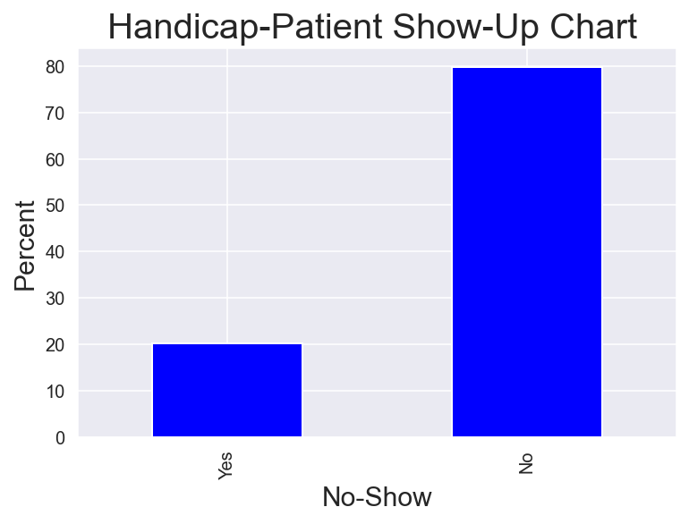

```python
df_handicap.plot(kind='bar', color='b');
plt.xlabel('No-Show', fontsize=15)
plt.ylabel('Percent', fontsize=15)
plt.title('Handicap-Patient Show-Up Chart ', fontsize=20)
#plt.legend(['Present', 'Absent'],  fontsize=15);
```

*Patients that are Handicap and hypertensive showed up more*

*Seems being handicap affects the show up of patients*

### Q5: Does disease affect the show-up of patients?

> Relationship of Diagnosis of all dieases with patient showing up

```python
df_diagnosis = df.groupby(['Hipertension','Diabetes','Alcoholism','Handicap'])['No-show']
df_diagnosis = pd.DataFrame(df_diagnosis.describe()['count'])
df_diagnosis
```

| Hipertension | Diabetes | Alcoholism | Handicap | count |
| --- | --- | --- | --- | --- |
| 0 | 0 | 0 | 0 | 84115 |
|  |  |  | 1 | 1088 |
|  |  |  | 2 | 97 |
|  |  |  | 3 | 9 |
|  |  |  | 4 | 3 |
|  |  | 1 | 0 | 1922 |
|  |  |  | 1 | 31 |
|  |  |  | 2 | 1 |
|  |  |  | 3 | 3 |
|  | 1 | 0 | 0 | 1341 |
|  |  |  | 1 | 39 |
|  |  |  | 2 | 1 |
|  |  | 1 | 0 | 75 |
|  |  |  | 1 | 1 |
| 1 | 0 | 0 | 0 | 13663 |
|  |  |  | 1 | 541 |
|  |  |  | 2 | 39 |
|  |  |  | 3 | 1 |
|  |  | 1 | 0 | 1042 |
|  |  |  | 1 | 26 |
|  |  |  | 2 | 3 |
|  | 1 | 0 | 0 | 5885 |
|  |  |  | 1 | 304 |
|  |  |  | 2 | 41 |
|  |  | 1 | 0 | 243 |
|  |  |  | 1 | 12 |
|  |  |  | 2 | 1 |

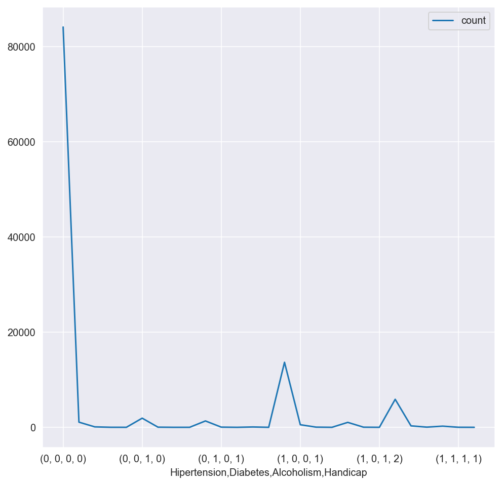

```python
df_diagnosis.plot(kind ='line', figsize =(8,8));
```

```python
f"{round(percentage(len(df)-df_diagnosis['count'][0][0][0][0],df), 2)}%"
```

```
'23.9%'
```

*i.e 24% shows how disease affects the show up of patients with Hypertension, Diabetes, Alcoholism and Handicap which is low*

## Q6: What month had the most appointment? Does month affect the show up of patients?

```python
df['AppointmentDate'] = df['AppointmentDay'].dt.date
df['AppointmentDate']
```

```
0         2016-04-29
1         2016-04-29
2         2016-04-29
3         2016-04-29
4         2016-04-29
             ...
110522    2016-06-07
110523    2016-06-07
110524    2016-06-07
110525    2016-06-07
110526    2016-06-07
Name: AppointmentDate, Length: 110527, dtype: object
```

```python
df['mnth_show']= df['AppointmentDay'].dt.month
df_MonthAppointment = df[['AppointmentDate', 'mnth_show', 'No-show']]
df_MonthAppointment = percentage(df_MonthAppointment.groupby(['mnth_show', 'No-show']).count(), df)
df_MonthAppointment
```

| mnth_show | No-show | AppointmentDate |
| --- | --- | --- |
| 4 | No | 2.354176 |
|  | Yes | 0.572711 |
| 5 | No | 57.937879 |
|  | Yes | 15.203525 |
| 6 | No | 19.514689 |
|  | Yes | 4.417020 |

```python
df_MonthAppointment = df_MonthAppointment.pivot_table(values='AppointmentDate', index='mnth_show', columns='No-show')
df_MonthAppointment
```

| No-show mnth_show | No | Yes |
| --- | --- | --- |
| 4 | 2.354176 | 0.572711 |
| 5 | 57.937879 | 15.203525 |
| 6 | 19.514689 | 4.417020 |

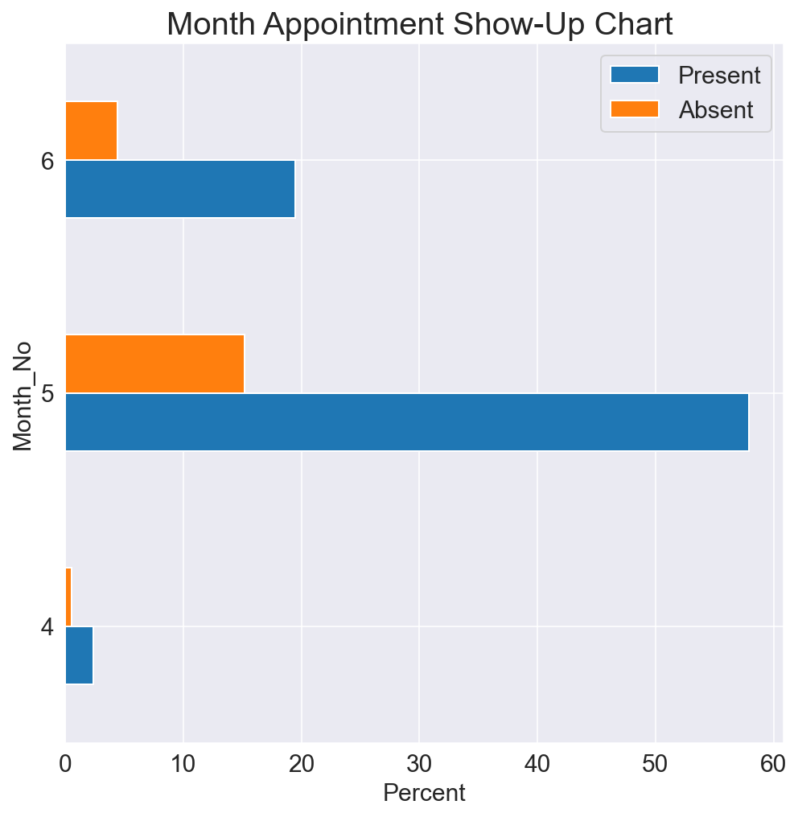

```python
df_MonthAppointment.plot(kind='barh', figsize=(8,8), fontsize=15);
plt.xlabel('Percent', fontsize=15)
plt.ylabel('Month_No', fontsize=15)
plt.title('Month Appointment Show-Up Chart ', fontsize=20)
plt.legend(['Present', 'Absent'],  fontsize=15);
```

*From the bar chart above, we can see that the month of appointment affects the show up of patient {Month of May}*

## Q7: Does sms alert affect the showup of patients for an appointment

*if this affects why more female patients showed up for an appointment*

```python
#In percentage
round(percentage(df['SMS_received'].value_counts(),df))
```

```
0    68.0
1    32.0
Name: SMS_received, dtype: float64
```

```python
# in percentage
df_smsAlert = round(df.groupby('SMS_received')['No-show'].value_counts()/len(df)*100).unstack()
df_smsAlert
```

| No-show SMS_received | No | Yes |
| --- | --- | --- |
| 0 | 57.0 | 11.0 |
| 1 | 23.0 | 9.0 |

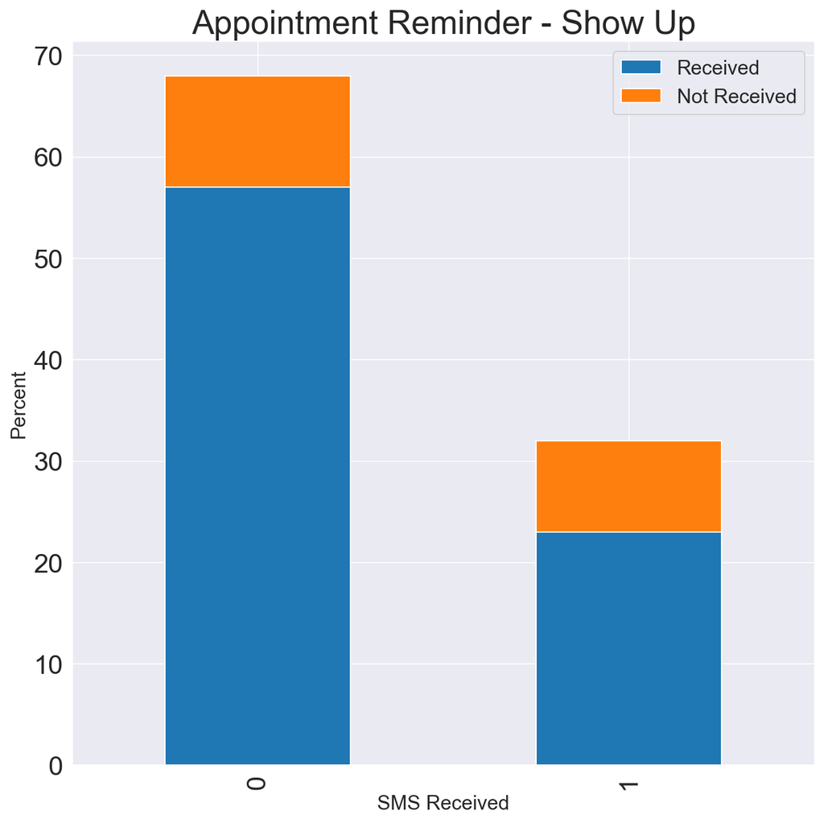

```python
#sms_show.index = ['Not Received','Received']
df_smsAlert.plot(kind = 'bar', figsize = (10,10), stacked = True, fontsize=20);
plt.title("Appointment Reminder - Show Up", fontsize=25)
plt.legend(["Received","Not Received"], fontsize = 15)
plt.ylabel("Percent", fontsize=15)
plt.xlabel("SMS Received", fontsize=15);
```

*we can see that 32% of patients got at least an sms but only 23% showed up compared to 68% of patients not getting an sms but only 57% were around; so sms does not affect the the show up of patient*

## Q8: Does scholarsihp affect the show up of patients?

```python
df_scholarship = (df.groupby(['Scholarship','No-show']).count())*100/(len(df))
df_scholarship = df_scholarship.pivot_table(values='PatientId', index='Scholarship', columns='No-show')
df_scholarship
```

| No-show Scholarship | No | Yes |
| --- | --- | --- |
| 0 | 72.312648 | 17.860794 |
| 1 | 7.494096 | 2.332462 |

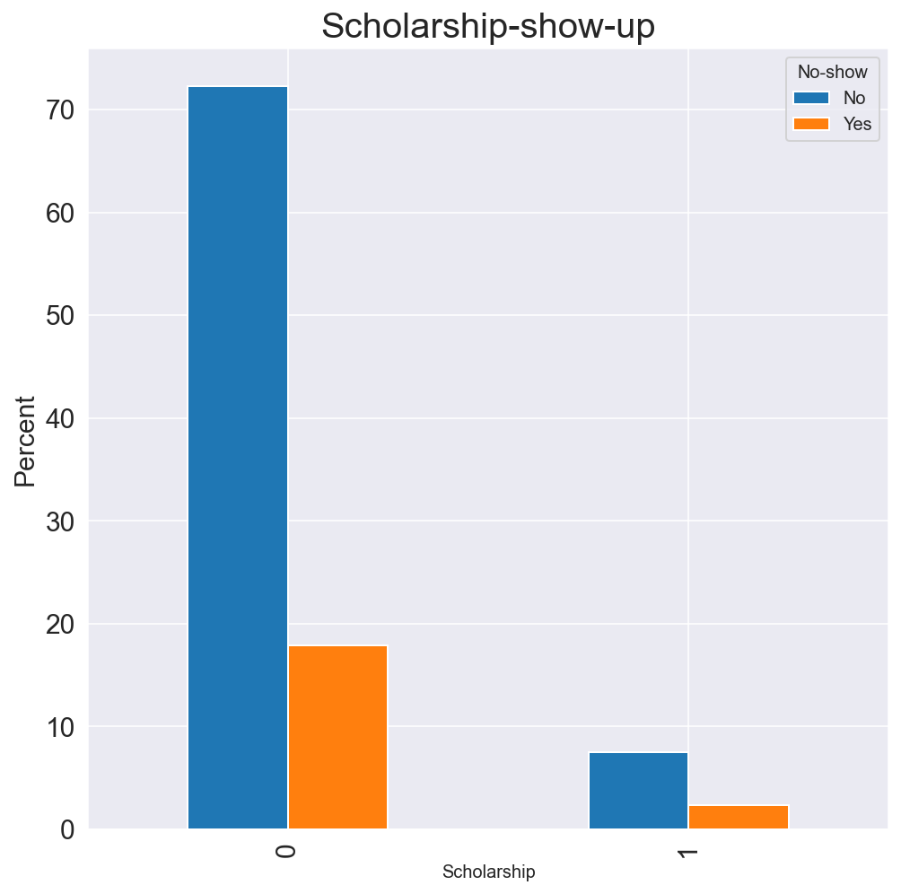

```python
df_scholarship.plot(kind='bar', figsize=(8, 8), fontsize=15)
plt.title("Scholarship-show-up", fontsize=20)
plt.ylabel("Percent", fontsize=15);
```

*We can see about 10% of the patient got a scholarship but 7.5% showed up: i.e Scholarship has no effect on the show up of patient*

## Q9 : Does location of patients affect their show up?

```python
df_Nationality = df
df_Nationality = df_Nationality.groupby(['Neighbourhood','No-show']).count()['PatientId']
df_Nationality.sort_values(ascending=False).head(10)
```

```
Neighbourhood    No-show
JARDIM CAMBURI   No         6252
MARIA ORTIZ      No         4586
RESISTÊNCIA      No         3525
JARDIM DA PENHA  No         3246
SANTA MARTHA     No         2635
CENTRO           No         2631
ITARARÉ          No         2591
TABUAZEIRO       No         2559
SANTO ANTÔNIO    No         2262
BONFIM           No         2223
Name: PatientId, dtype: int64
```

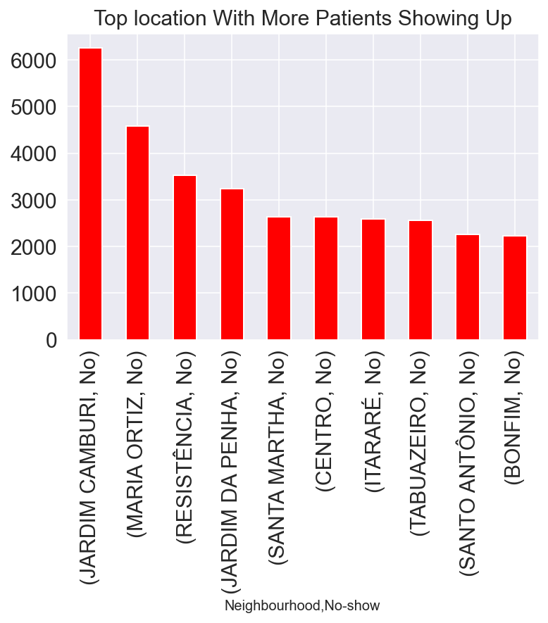

```python
df_Nationality.sort_values(ascending=False).head(10).plot(kind='bar', color='r', fontsize=15);
plt.title('Top location With More Patients Showing Up', fontsize=15)
```

*More patient from JARDIM CAMBURI shows up the more*

##### Conclusion - Communication

*1. Patient Age has a relationship on the show up of patient.*

*2. More Females showed up for their appointment i.e they seems to be more concious of their health*

*3. SMS alert has no impact to the show up of patients*

*4. Appointment Date affects the show up of patients*

*5. Diease does not affect the show up of patients*

*6. being handicapped affects the show up of patients*

*7. Scolarship has no impact of the show up of patient*

Resources: towardsdatascience.com, pandas.pydata.org and Kaggle.com

##### Limitations

1. Some other factors e.g weather, transportation etc could be the cause as to why some patients could not meetup for the appointment day
2. Distance of Patient's location to the Hospital is also a limitation since the dataset didnt contain distance(metre) of a location to the clinic